# Train Image Model 2 - Structure of CNN based on that used in Atari paper

## Imports

```python
import os
import cv2
import random
import numpy as np
import pandas as pd
import pickle

import matplotlib.pyplot as plt
%matplotlib inline
from matplotlib import ticker
import seaborn as sns

from sklearn.model_selection import train_test_split
from sklearn import metrics
from imblearn.under_sampling import RandomUnderSampler
from sklearn.utils import shuffle

import keras
from keras.models import Sequential
from keras.layers import Input, Dropout, Flatten, Conv2D, MaxPooling2D, Dense, Activation
from keras.optimizers import RMSprop, adam
from keras.utils import np_utils
```

## Preparing the Data

### Load Images

Loads a set of images and resizes each image to 64x64 and coverts to black and white.

```python
# Set up some parmaeters for data loading
TRAIN_DIR = './data/'
sample_rate = 0.9
ROWS = 64
COLS = 64
CHANNELS = 1

# generate filenames from the data folder and do sampling
image_filenames = [TRAIN_DIR+i for i in os.listdir(TRAIN_DIR) if not i.startswith('.')] # use this for full dataset
image_filenames = random.sample(image_filenames, int(len(image_filenames)*sample_rate))

# Create a data array for image data
count = len(image_filenames)
data = np.ndarray((count, CHANNELS, ROWS, COLS), dtype=np.float)

# Iterate throuigh the filenames and for each one load the image, resize and normalise
for i, image_file in enumerate(image_filenames):
    image = cv2.imread(image_file, cv2.IMREAD_GRAYSCALE)
    image = cv2.resize(image, (ROWS, COLS), interpolation=cv2.INTER_CUBIC)
    data[i] = image
    data[i] = data[i]/255
    if i%1000 == 0: print('Processed {} of {}'.format(i, count))

print("Train shape: {}".format(data.shape))
```

```
Processed 0 of 28241
Processed 1000 of 28241
Processed 2000 of 28241
Processed 3000 of 28241
Processed 4000 of 28241
Processed 5000 of 28241
Processed 6000 of 28241
Processed 7000 of 28241
Processed 8000 of 28241
Processed 9000 of 28241
Processed 10000 of 28241
Processed 11000 of 28241
Processed 12000 of 28241
Processed 13000 of 28241
Processed 14000 of 28241
Processed 15000 of 28241
Processed 16000 of 28241
Processed 17000 of 28241
Processed 18000 of 28241
Processed 19000 of 28241
Processed 20000 of 28241
Processed 21000 of 28241
Processed 22000 of 28241
Processed 23000 of 28241
Processed 24000 of 28241
Processed 25000 of 28241
Processed 26000 of 28241
Processed 27000 of 28241
Processed 28000 of 28241
Train shape: (28241, 1, 64, 64)
```

### Generating the Labels

We're dealing with a multi-class classification problem here - (0) no action, (1) left, (2) up, and (3) right. The lables can be created by looping over the file names in the train directory.

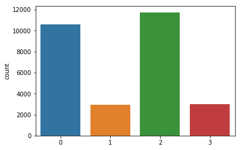

```python
# Extract the lables from the last characters in the filename
labels = []
for i in image_filenames:
    l = i[-6:-5]
    labels.append(int(l))

# Count the number of clases
num_classes = len(set(labels))

# convert to binary encoded labels
labels_wide = keras.utils.to_categorical(labels, num_classes)

# Plot a bar plot of the
sns.countplot(labels)
```

### Show some screens

Print a few screens with their labels.

```
2
```

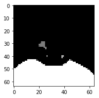

```
0
```

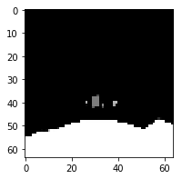

```
0
```

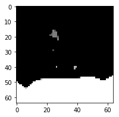

```
3
```

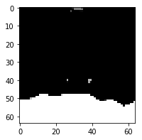

```
0
```

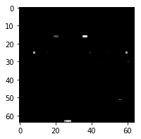

```python
for i in range(0,5):
    idx = random.randint(0, len(labels))
    print(labels[idx])
    plt.figure(figsize=(3,3))
    plt.imshow(data[idx][0], cmap='gray')
    plt.show()
```

### Partition the dataset for evaluation

Split the data into a training and test partition so we can evaluate at the end

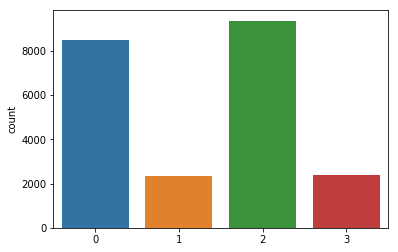

```python
train, test, train_labels, test_labels = train_test_split(data, labels, random_state=0, test_size = 0.2, train_size = 0.8)
train_labels_wide = keras.utils.to_categorical(train_labels, num_classes)
test_labels_wide = keras.utils.to_categorical(test_labels, num_classes)
sns.countplot(train_labels)
```

Don't apply under sampling to balance the training dataset, because half of the data will be lost.

## LunarLanderNet

A simple convolutional network to control the lander.

```python
model = Sequential()
model.add(Conv2D(32, kernel_size=(8, 8), padding='same', input_shape=(CHANNELS, ROWS, COLS), subsample=(4, 4)))
model.add(Activation('relu'))
model.add(Conv2D(64,  kernel_size=(4, 4), subsample=(2, 2)))
model.add(Activation('relu'))
model.add(Conv2D(64,  kernel_size=(3, 3), subsample=(1, 1)))
model.add(Activation('relu'))
model.add(Flatten())
model.add(Dense(16))
model.add(Activation('relu'))
model.add(Dense(4))
model.add(Activation('softmax'))
model.summary()
```

```
_________________________________________________________________
Layer (type)                 Output Shape              Param #
=================================================================
conv2d_1 (Conv2D)            (None, 32, 16, 16)        2080
_________________________________________________________________
activation_1 (Activation)    (None, 32, 16, 16)        0
_________________________________________________________________
conv2d_2 (Conv2D)            (None, 64, 7, 7)          32832
_________________________________________________________________
activation_2 (Activation)    (None, 64, 7, 7)          0
_________________________________________________________________
conv2d_3 (Conv2D)            (None, 64, 5, 5)          36928
_________________________________________________________________
activation_3 (Activation)    (None, 64, 5, 5)          0
_________________________________________________________________
flatten_1 (Flatten)          (None, 1600)              0
_________________________________________________________________
dense_1 (Dense)              (None, 16)                25616
_________________________________________________________________
activation_4 (Activation)    (None, 16)                0
_________________________________________________________________
dense_2 (Dense)              (None, 4)                 68
_________________________________________________________________
activation_5 (Activation)    (None, 4)                 0
=================================================================
Total params: 97,524
Trainable params: 97,524
Non-trainable params: 0
_________________________________________________________________
```

```python
model.compile(loss='categorical_crossentropy', optimizer=adam(lr=1e-3), metrics=['accuracy'])
```

### Train

Train a model.

```python
epochs = 70
batch_size = 128

history = model.fit(train, train_labels_wide, batch_size=batch_size, epochs=epochs, validation_split=0.25, verbose=1, shuffle=True)
# batch size so it runs through 128 examples before learning
```

```
Train on 16944 samples, validate on 5648 samples
```

Plot the evolution of the loss as the module was trained.

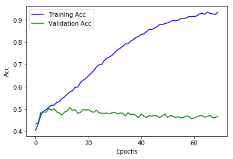

```python
acc = history.history['acc']
val_acc = history.history['val_acc']

plt.xlabel('Epochs')
plt.ylabel('Acc')
plt.plot(acc, 'blue', label='Training Acc')
plt.plot(val_acc, 'green', label='Validation Acc')
plt.xticks(range(0,epochs)[0::20])
plt.legend()
plt.show()
```

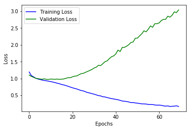

```python
loss = history.history['loss']
val_loss = history.history['val_loss']

plt.xlabel('Epochs')
plt.ylabel('Loss')
plt.plot(loss, 'blue', label='Training Loss')
plt.plot(val_loss, 'green', label='Validation Loss')
plt.xticks(range(0,epochs)[0::20])
plt.legend()
plt.show()
```

### Evaluate the Model

Use the test dataset to evaluate the model

```python
pred = model.predict_classes(test)

accuracy = metrics.accuracy_score(test_labels, pred) # , normalize=True, sample_weight=None
print("Accuracy: " +  str(accuracy))

print("****** Test Data ********")
# Make a set of predictions for the validation data
pred = model.predict_classes(test)

# Print performance details
print(metrics.classification_report(test_labels, pred))

# Print confusion matrix
print("Confusion Matrix")
print(metrics.confusion_matrix(test_labels, pred))
#display(pd.crosstab(test_labels, list(pred), margins=True))
```

```
Accuracy: 0.46999468932554433
****** Test Data ********
             precision    recall  f1-score   support

          0       0.41      0.41      0.41      2086
          1       0.62      0.52      0.57       593
          2       0.47      0.51      0.49      2383
          3       0.62      0.48      0.54       587

avg / total       0.48      0.47      0.47      5649

Confusion Matrix
[[ 853   82 1078   73]
 [ 118  308  146   21]
 [ 988  100 1214   81]
 [ 141    4  162  280]]
```

### Persist A Model

Save the model

```python
filepath = "image_mod2.mod"
model.save(filepath)

with open('history_image2.pckl','wb') as f:
    pickle.dump(history.history, f)
f.close()
```

```python
# serialize model to JSON
model_json = model.to_json()
with open("image_mod2.json", "w") as json_file:
    json_file.write(model_json)
json_file.close()
# serialize weights to HDF5
model.save_weights("image_mod2.h5")
print("Saved model to disk")
```

```
Saved model to disk
```